# about.Rmd

Katherine Wang

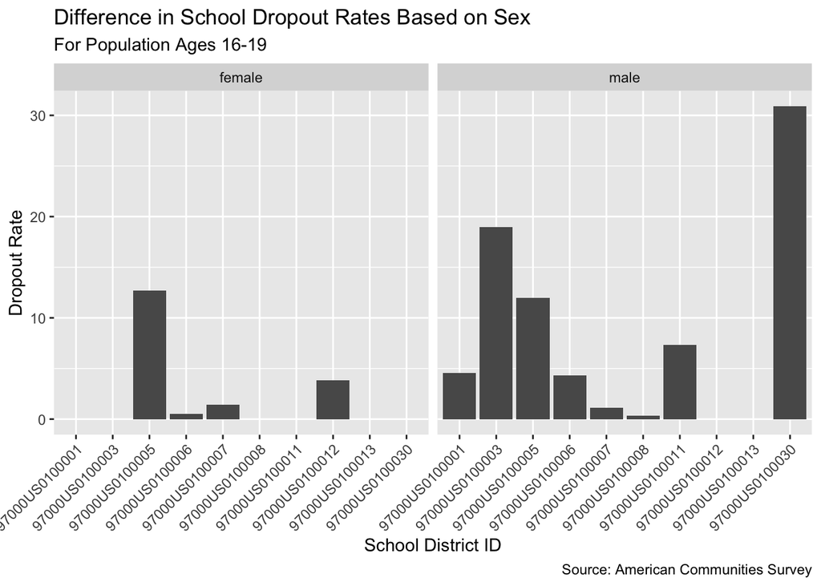

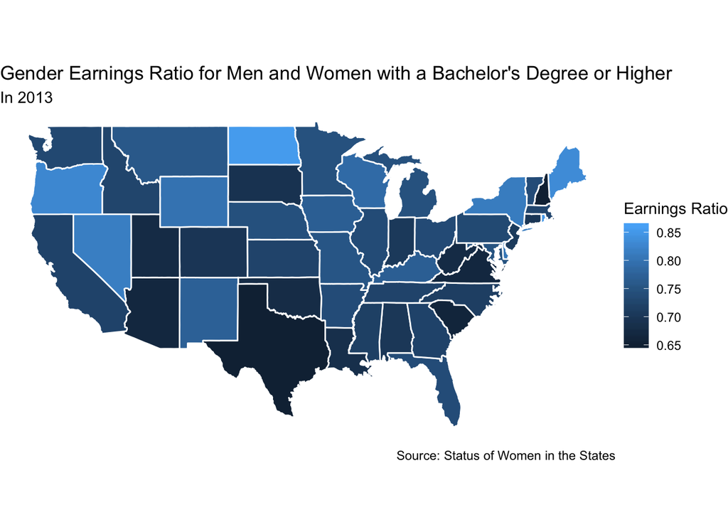

**Background**

The goal of this project is to discover the extent to which a school’s inequality mirrors that of its community’s. Although some believe that schools act as the springboard of social equality and progress, others argue that schools merely reinforce the existing stratification found in their societies. In order to test the idea of whether schools serve as social mirrors, I will analyze two main forms of inequality, race and gender, in two separate spheres – the school and the community. Ultimately, I hope to discover whether a correlative relationship exists between inequality in a community and inequality in schools.

I gathered my data from two sources: the American Community Surveys (ACS) from the US Census Bureau and the Status of Women in the States. From ACS’ data, I extracted information about each school district’s distribution of race and gender, unemployment rate by race and gender, average household income by race, and school dropout rate by sex. From the data from the Status of Women in the States, I was able to analyze the gender gap in earnings to try to evaluate a community’s level of gender inequality. Although I downloaded data from the National Center for Education Statistics (NCES), which included data on school enrollments by race and sex, I am not sure if I will be implementing it as of now.

Currently, I have created a graphic displaying levels of gender inequality in communities, as well as a chart showing gender inequality in schools in terms of dropout rates. I will create more graphics regarding racial inequality, and I hope to find a way to combine the different graphs I make.

Url to my repo: https://github.com/katherinewang122/Final-Project-Milestone-3.git